[Edit on GitHub](https://github.com/arviz-devs/ArviZ.jl/blob/main/docs/src/quickstart.jl)

# ArviZ.jl Quickstart

Note

This tutorial is adapted from [ArviZ's quickstart](https://python.arviz.org/en/latest/getting_started/Introduction.html).

## Setup

Here we add the necessary packages for this notebook and load a few we will use throughout.

```julia
begin
    using ArviZ, CmdStan, Distributions, LinearAlgebra, PyPlot, Random, Soss, Turing
    using Soss.MeasureTheory: HalfCauchy
    using SampleChainsDynamicHMC: getchains, dynamichmc
end
```

```julia
# ArviZ ships with style sheets!
ArviZ.use_style("arviz-darkgrid")
```

## Get started with plotting

ArviZ.jl is designed to be used with libraries like [CmdStan](https://github.com/StanJulia/CmdStan.jl), [Turing.jl](https://turing.ml), and Soss.jl but works fine with raw arrays.

```julia
rng1 = Random.MersenneTwister(37772);
```

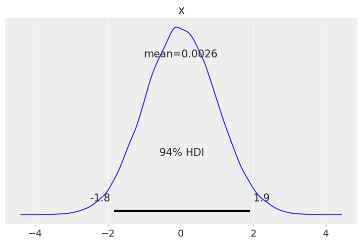

```julia
begin
    plot_posterior(randn(rng1, 100_000))
    gcf()
end
```

Plotting a dictionary of arrays, ArviZ.jl will interpret each key as the name of a different random variable. Each row of an array is treated as an independent series of draws from the variable, called a *chain*. Below, we have 10 chains of 50 draws each for four different distributions.

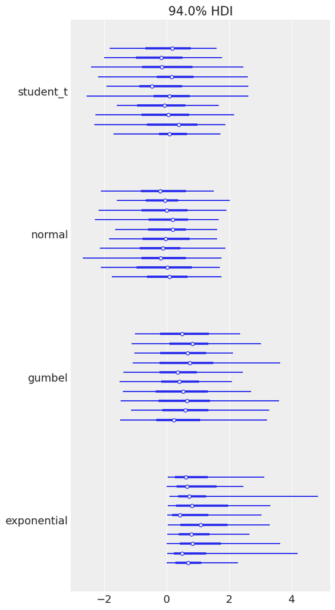

```julia
let
    s = (10, 50)
    plot_forest((
        normal=randn(rng1, s),
        gumbel=rand(rng1, Gumbel(), s),
        student_t=rand(rng1, TDist(6), s),
        exponential=rand(rng1, Exponential(), s),
    ),)
    gcf()
end
```

## Plotting with MCMCChains.jl's `Chains` objects produced by Turing.jl

ArviZ is designed to work well with high dimensional, labelled data. Consider the [eight schools model](https://statmodeling.stat.columbia.edu/2014/01/21/everything-need-know-bayesian-statistics-learned-eight-schools/), which roughly tries to measure the effectiveness of SAT classes at eight different schools. To show off ArviZ's labelling, I give the schools the names of [a different eight schools](https://en.wikipedia.org/wiki/Eight_Schools_Association).

This model is small enough to write down, is hierarchical, and uses labelling. Additionally, a centered parameterization causes [divergences](https://mc-stan.org/users/documentation/case-studies/divergences_and_bias.html) (which are interesting for illustration).

First we create our data and set some sampling parameters.

```julia
begin
    J = 8
    y = [28.0, 8.0, -3.0, 7.0, -1.0, 1.0, 18.0, 12.0]
    σ = [15.0, 10.0, 16.0, 11.0, 9.0, 11.0, 10.0, 18.0]
    schools = [
        "Choate",
        "Deerfield",
        "Phillips Andover",
        "Phillips Exeter",
        "Hotchkiss",
        "Lawrenceville",
        "St. Paul's",
        "Mt. Hermon",
    ]
    ndraws = 1_000
    ndraws_warmup = 1_000
    nchains = 4
end;
```

Now we write and run the model using Turing:

```julia
Turing.@model function model_turing(y, σ, J=length(y))
    μ ~ Normal(0, 5)
    τ ~ truncated(Cauchy(0, 5), 0, Inf)
    θ ~ filldist(Normal(μ, τ), J)
    for i in 1:J
        y[i] ~ Normal(θ[i], σ[i])
    end
end
```

```
model_turing (generic function with 3 methods)
```

```julia
rng2 = Random.MersenneTwister(16653);
```

```julia
begin
    param_mod_turing = model_turing(y, σ)
    sampler = NUTS(ndraws_warmup, 0.8)

    turing_chns = Turing.sample(
        rng2, model_turing(y, σ), sampler, MCMCThreads(), ndraws, nchains
    )
end;
```

Most ArviZ functions work fine with `Chains` objects from Turing:

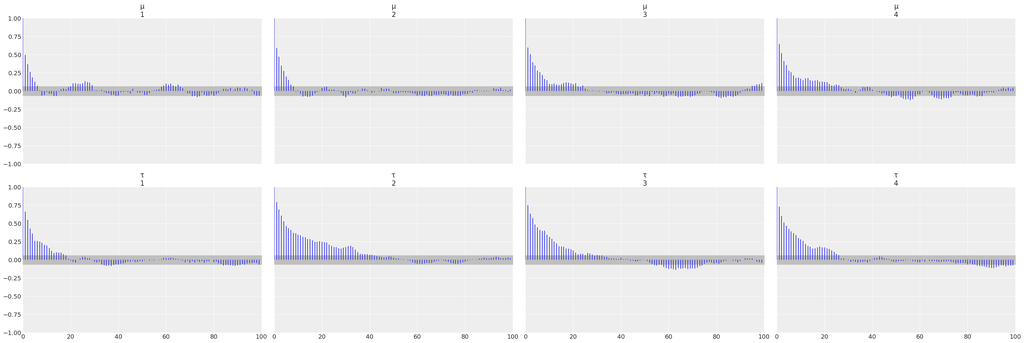

```julia
begin
    plot_autocorr(turing_chns; var_names=(:μ, :τ))
    gcf()
end
```

### Convert to `InferenceData`

For much more powerful querying, analysis and plotting, we can use built-in ArviZ utilities to convert `Chains` objects to multidimensional data structures with named dimensions and indices. Note that for such dimensions, the information is not contained in `Chains`, so we need to provide it.

ArviZ is built to work with [`InferenceData`](https://julia.arviz.org/stable/reference/#ArviZ.InferenceData), and the more *groups* it has access to, the more powerful analyses it can perform.

```julia
idata_turing_post = from_mcmcchains(
    turing_chns;
    coords=(; school=schools),
    dims=NamedTuple(k => (:school,) for k in (:y, :σ, :θ)),
    library="Turing",
)
```

InferenceData

**posterior**

```
Dataset with dimensions:
  Dim{:chain} Sampled 1:4 ForwardOrdered Regular Points,
  Dim{:draw} Sampled 1:1000 ForwardOrdered Regular Points,
  Dim{:school} Categorical String[Choate, Deerfield, …, St. Paul's, Mt. Hermon] Unordered
and 3 layers:
  :μ Float64 dims: Dim{:chain}, Dim{:draw} (4×1000)
  :τ Float64 dims: Dim{:chain}, Dim{:draw} (4×1000)
  :θ Float64 dims: Dim{:chain}, Dim{:draw}, Dim{:school} (4×1000×8)

with metadata OrderedCollections.OrderedDict{Symbol, Any} with 4 entries:
  :created_at => "2022-07-27T05:42:10.685"
  :arviz_version => "0.6.0"
  :arviz_language => "julia"
  :inference_library => "Turing"
```

**sample_stats**

```
Dataset with dimensions:
  Dim{:chain} Sampled 1:4 ForwardOrdered Regular Points,
  Dim{:draw} Sampled 1:1000 ForwardOrdered Regular Points
and 12 layers:
  :energy           Float64 dims: Dim{:chain}, Dim{:draw} (4×1000)
  :n_steps          Int64 dims: Dim{:chain}, Dim{:draw} (4×1000)
  :diverging        Bool dims: Dim{:chain}, Dim{:draw} (4×1000)
  :max_energy_error Float64 dims: Dim{:chain}, Dim{:draw} (4×1000)
  :energy_error     Float64 dims: Dim{:chain}, Dim{:draw} (4×1000)
  :is_accept        Bool dims: Dim{:chain}, Dim{:draw} (4×1000)
  :log_density      Float64 dims: Dim{:chain}, Dim{:draw} (4×1000)
  :tree_depth       Int64 dims: Dim{:chain}, Dim{:draw} (4×1000)
  :step_size        Float64 dims: Dim{:chain}, Dim{:draw} (4×1000)
  :acceptance_rate  Float64 dims: Dim{:chain}, Dim{:draw} (4×1000)
  :lp               Float64 dims: Dim{:chain}, Dim{:draw} (4×1000)
  :step_size_nom    Float64 dims: Dim{:chain}, Dim{:draw} (4×1000)

with metadata OrderedCollections.OrderedDict{Symbol, Any} with 4 entries:
  :created_at => "2022-07-27T05:42:10.37"
  :arviz_version => "0.6.0"
  :arviz_language => "julia"
  :inference_library => "Turing"
```

Each group is an [`ArviZ.Dataset`](https://julia.arviz.org/stable/reference/#ArviZ.Dataset), a `DimensionalData.AbstractDimStack` that can be used identically to a [`DimensionalData.Dimstack`](https://rafaqz.github.io/DimensionalData.jl/stable/api/#DimensionalData.DimStack). We can view a summary of the dataset.

```julia
idata_turing_post.posterior
```

```
Dataset with dimensions:
  Dim{:chain} Sampled 1:4 ForwardOrdered Regular Points,
  Dim{:draw} Sampled 1:1000 ForwardOrdered Regular Points,
  Dim{:school} Categorical String[Choate, Deerfield, …, St. Paul's, Mt. Hermon] Unordered
and 3 layers:
  :μ Float64 dims: Dim{:chain}, Dim{:draw} (4×1000)
  :τ Float64 dims: Dim{:chain}, Dim{:draw} (4×1000)
  :θ Float64 dims: Dim{:chain}, Dim{:draw}, Dim{:school} (4×1000×8)

with metadata OrderedCollections.OrderedDict{Symbol, Any} with 4 entries:
  :created_at        => "2022-07-27T05:42:10.685"
  :arviz_version     => "0.6.0"
  :arviz_language    => "julia"
  :inference_library => "Turing"
```

Here is a plot of the trace. Note the intelligent labels.

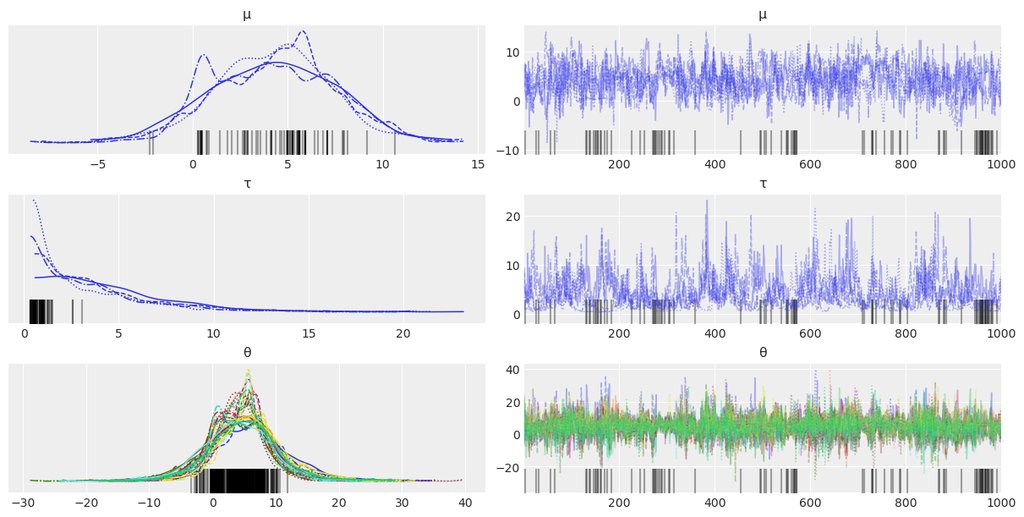

```julia
begin
    plot_trace(idata_turing_post)
    gcf()
end
```

We can also generate summary stats...

```julia
summarystats(idata_turing_post)
```

|  | variable | mean | sd | hdi_3% | hdi_97% | mcse_mean | mcse_sd | ess_bulk | ess_tail | r_hat |
| --- | --- | --- | --- | --- | --- | --- | --- | --- | --- | --- |
| 1 | "μ" | 4.263 | 3.199 | -1.375 | 10.43 | 0.134 | 0.095 | 571.0 | 967.0 | 1.0 |
| 2 | "τ" | 3.838 | 3.218 | 0.333 | 9.678 | 0.216 | 0.153 | 116.0 | 118.0 | 1.05 |
| 3 | "θ[Choate]" | 6.226 | 5.672 | -3.543 | 17.356 | 0.201 | 0.142 | 717.0 | 1237.0 | 1.01 |
| 4 | "θ[Deerfield]" | 4.817 | 4.76 | -4.284 | 13.68 | 0.156 | 0.11 | 836.0 | 1512.0 | 1.01 |
| 5 | "θ[Phillips Andover]" | 3.786 | 5.315 | -6.746 | 13.383 | 0.144 | 0.116 | 1239.0 | 1783.0 | 1.01 |
| 6 | "θ[Phillips Exeter]" | 4.616 | 4.85 | -4.367 | 13.962 | 0.135 | 0.099 | 1060.0 | 1917.0 | 1.01 |
| 7 | "θ[Hotchkiss]" | 3.343 | 4.72 | -5.927 | 11.836 | 0.169 | 0.119 | 765.0 | 1433.0 | 1.01 |
| 8 | "θ[Lawrenceville]" | 3.869 | 5.016 | -5.091 | 14.342 | 0.139 | 0.109 | 1149.0 | 1732.0 | 1.01 |
| 9 | "θ[St. Paul's]" | 6.259 | 5.083 | -2.895 | 16.392 | 0.187 | 0.133 | 668.0 | 1115.0 | 1.01 |
| 10 | "θ[Mt. Hermon]" | 4.879 | 5.48 | -5.39 | 15.789 | 0.153 | 0.123 | 1089.0 | 1735.0 | 1.01 |

...and examine the energy distribution of the Hamiltonian sampler.

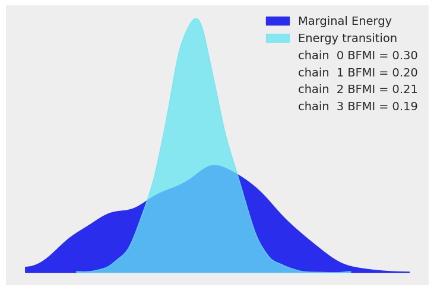

```julia
begin
    plot_energy(idata_turing_post)
    gcf()
end
```

### Additional information in Turing.jl

With a few more steps, we can use Turing to compute additional useful groups to add to the `InferenceData`.

To sample from the prior, one simply calls `sample` but with the `Prior` sampler:

```julia
prior = Turing.sample(rng2, param_mod_turing, Prior(), ndraws);
```

To draw from the prior and posterior predictive distributions we can instantiate a "predictive model", i.e. a Turing model but with the observations set to `missing`, and then calling `predict` on the predictive model and the previously drawn samples:

```julia
begin
    # Instantiate the predictive model
    param_mod_predict = model_turing(similar(y, Missing), σ)
    # and then sample!
    prior_predictive = Turing.predict(rng2, param_mod_predict, prior)
    posterior_predictive = Turing.predict(rng2, param_mod_predict, turing_chns)
end;
```

And to extract the pointwise log-likelihoods, which is useful if you want to compute metrics such as [`loo`](https://julia.arviz.org/stable/reference/#ArviZ.loo),

```julia
log_likelihood = let
    log_likelihood = Turing.pointwise_loglikelihoods(
        param_mod_turing, MCMCChains.get_sections(turing_chns, :parameters)
    )
    # Ensure the ordering of the loglikelihoods matches the ordering of `posterior_predictive`
    ynames = string.(keys(posterior_predictive))
    log_likelihood_y = getindex.(Ref(log_likelihood), ynames)
    # Reshape into `(nchains, ndraws, size(y)...)`
    (; y=permutedims(cat(log_likelihood_y...; dims=3), (2, 1, 3)))
end;
```

This can then be included in the [`from_mcmcchains`](https://julia.arviz.org/stable/reference/#ArviZ.from_mcmcchains) call from above:

```julia
idata_turing = from_mcmcchains(
    turing_chns;
    posterior_predictive,
    log_likelihood,
    prior,
    prior_predictive,
    observed_data=(; y),
    coords=(; school=schools),
    dims=NamedTuple(k => (:school,) for k in (:y, :σ, :θ)),
    library=Turing,
)
```

InferenceData

**posterior**

```
Dataset with dimensions:
  Dim{:chain} Sampled 1:4 ForwardOrdered Regular Points,
  Dim{:draw} Sampled 1:1000 ForwardOrdered Regular Points,
  Dim{:school} Categorical String[Choate, Deerfield, …, St. Paul's, Mt. Hermon] Unordered
and 3 layers:
  :μ Float64 dims: Dim{:chain}, Dim{:draw} (4×1000)
  :τ Float64 dims: Dim{:chain}, Dim{:draw} (4×1000)
  :θ Float64 dims: Dim{:chain}, Dim{:draw}, Dim{:school} (4×1000×8)

with metadata OrderedCollections.OrderedDict{Symbol, Any} with 5 entries:
  :created_at => "2022-07-27T05:42:52.394"
  :arviz_version => "0.6.0"
  :arviz_language => "julia"
  :inference_library => "Turing"
  :inference_library_version => "0.21.9"
```

**posterior_predictive**

```
Dataset with dimensions:
  Dim{:chain} Sampled 1:4 ForwardOrdered Regular Points,
  Dim{:draw} Sampled 1:1000 ForwardOrdered Regular Points,
  Dim{:school} Categorical String[Choate, Deerfield, …, St. Paul's, Mt. Hermon] Unordered
and 1 layer:
  :y Float64 dims: Dim{:chain}, Dim{:draw}, Dim{:school} (4×1000×8)

with metadata OrderedCollections.OrderedDict{Symbol, Any} with 5 entries:
  :created_at => "2022-07-27T05:42:51.555"
  :arviz_version => "0.6.0"
  :arviz_language => "julia"
  :inference_library => "Turing"
  :inference_library_version => "0.21.9"
```

**log_likelihood**

```
Dataset with dimensions:
  Dim{:chain} Sampled 1:4 ForwardOrdered Regular Points,
  Dim{:draw} Sampled 1:1000 ForwardOrdered Regular Points,
  Dim{:school} Categorical String[Choate, Deerfield, …, St. Paul's, Mt. Hermon] Unordered
and 1 layer:
  :y Float64 dims: Dim{:chain}, Dim{:draw}, Dim{:school} (4×1000×8)

with metadata OrderedCollections.OrderedDict{Symbol, Any} with 5 entries:
  :created_at => "2022-07-27T05:42:52.071"
  :arviz_version => "0.6.0"
  :arviz_language => "julia"
  :inference_library => "Turing"
  :inference_library_version => "0.21.9"
```

**sample_stats**

```
Dataset with dimensions:
  Dim{:chain} Sampled 1:4 ForwardOrdered Regular Points,
  Dim{:draw} Sampled 1:1000 ForwardOrdered Regular Points
and 12 layers:
  :energy           Float64 dims: Dim{:chain}, Dim{:draw} (4×1000)
  :n_steps          Int64 dims: Dim{:chain}, Dim{:draw} (4×1000)
  :diverging        Bool dims: Dim{:chain}, Dim{:draw} (4×1000)
  :max_energy_error Float64 dims: Dim{:chain}, Dim{:draw} (4×1000)
  :energy_error     Float64 dims: Dim{:chain}, Dim{:draw} (4×1000)
  :is_accept        Bool dims: Dim{:chain}, Dim{:draw} (4×1000)
  :log_density      Float64 dims: Dim{:chain}, Dim{:draw} (4×1000)
  :tree_depth       Int64 dims: Dim{:chain}, Dim{:draw} (4×1000)
  :step_size        Float64 dims: Dim{:chain}, Dim{:draw} (4×1000)
  :acceptance_rate  Float64 dims: Dim{:chain}, Dim{:draw} (4×1000)
  :lp               Float64 dims: Dim{:chain}, Dim{:draw} (4×1000)
  :step_size_nom    Float64 dims: Dim{:chain}, Dim{:draw} (4×1000)

with metadata OrderedCollections.OrderedDict{Symbol, Any} with 5 entries:
  :created_at => "2022-07-27T05:42:52.393"
  :arviz_version => "0.6.0"
  :arviz_language => "julia"
  :inference_library => "Turing"
  :inference_library_version => "0.21.9"
```

**prior**

```
Dataset with dimensions:
  Dim{:chain} Sampled 1:1 ForwardOrdered Regular Points,
  Dim{:draw} Sampled 1:1000 ForwardOrdered Regular Points,
  Dim{:school} Categorical String[Choate, Deerfield, …, St. Paul's, Mt. Hermon] Unordered
and 3 layers:
  :μ Float64 dims: Dim{:chain}, Dim{:draw} (1×1000)
  :τ Float64 dims: Dim{:chain}, Dim{:draw} (1×1000)
  :θ Float64 dims: Dim{:chain}, Dim{:draw}, Dim{:school} (1×1000×8)

with metadata OrderedCollections.OrderedDict{Symbol, Any} with 5 entries:
  :created_at => "2022-07-27T05:42:54.158"
  :arviz_version => "0.6.0"
  :arviz_language => "julia"
  :inference_library => "Turing"
  :inference_library_version => "0.21.9"
```

**prior_predictive**

```
Dataset with dimensions:
  Dim{:chain} Sampled 1:1 ForwardOrdered Regular Points,
  Dim{:draw} Sampled 1:1000 ForwardOrdered Regular Points,
  Dim{:school} Categorical String[Choate, Deerfield, …, St. Paul's, Mt. Hermon] Unordered
and 1 layer:
  :y Float64 dims: Dim{:chain}, Dim{:draw}, Dim{:school} (1×1000×8)

with metadata OrderedCollections.OrderedDict{Symbol, Any} with 5 entries:
  :created_at => "2022-07-27T05:42:53.439"
  :arviz_version => "0.6.0"
  :arviz_language => "julia"
  :inference_library => "Turing"
  :inference_library_version => "0.21.9"
```

**sample_stats_prior**

```
Dataset with dimensions:
  Dim{:chain} Sampled 1:1 ForwardOrdered Regular Points,
  Dim{:draw} Sampled 1:1000 ForwardOrdered Regular Points
and 1 layer:
  :lp Float64 dims: Dim{:chain}, Dim{:draw} (1×1000)

with metadata OrderedCollections.OrderedDict{Symbol, Any} with 5 entries:
  :created_at => "2022-07-27T05:42:53.753"
  :arviz_version => "0.6.0"
  :arviz_language => "julia"
  :inference_library => "Turing"
  :inference_library_version => "0.21.9"
```

**observed_data**

```
Dataset with dimensions:
  Dim{:school} Categorical String[Choate, Deerfield, …, St. Paul's, Mt. Hermon] Unordered
and 1 layer:
  :y Float64 dims: Dim{:school} (8)

with metadata OrderedCollections.OrderedDict{Symbol, Any} with 5 entries:
  :created_at => "2022-07-27T05:42:54.73"
  :arviz_version => "0.6.0"
  :arviz_language => "julia"
  :inference_library => "Turing"
  :inference_library_version => "0.21.9"
```

```julia
loo(idata_turing; pointwise=false) # higher is better
```

|  | loo | loo_se | p_loo | n_samples | n_data_points | warning | loo_scale |
| --- | --- | --- | --- | --- | --- | --- | --- |
| 1 | -30.7102 | 1.3612 | 0.85832 | 4000 | 8 | false | "log" |

If the model is well-calibrated, i.e. it replicates the true generative process well, the CDF of the pointwise LOO values should be similarly distributed to a uniform distribution. This can be inspected visually:

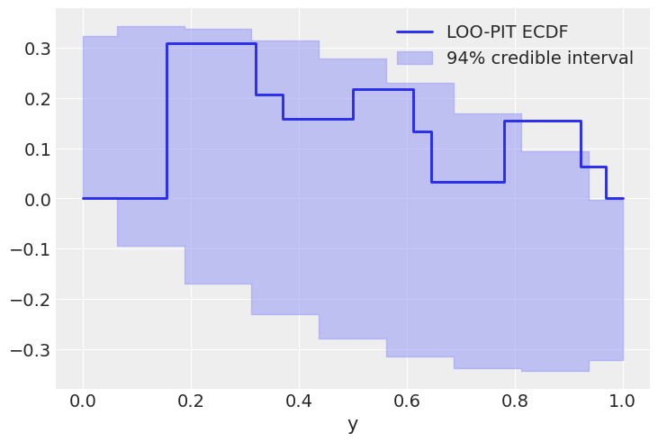

```julia
begin
    plot_loo_pit(idata_turing; y=:y, ecdf=true)
    gcf()
end
```

## Plotting with CmdStan.jl outputs

CmdStan.jl and StanSample.jl also default to producing `Chains` outputs, and we can easily plot these chains.

Here is the same centered eight schools model:

```julia
begin
    schools_code = """
    data {
      int<lower=0> J;
      real y[J];
      real<lower=0> sigma[J];
    }

    parameters {
      real mu;
      real<lower=0> tau;
      real theta[J];
    }

    model {
      mu ~ normal(0, 5);
      tau ~ cauchy(0, 5);
      theta ~ normal(mu, tau);
      y ~ normal(theta, sigma);
    }

    generated quantities {
        vector[J] log_lik;
        vector[J] y_hat;
        for (j in 1:J) {
            log_lik[j] = normal_lpdf(y[j] | theta[j], sigma[j]);
            y_hat[j] = normal_rng(theta[j], sigma[j]);
        }
    }
    """

    schools_data = Dict("J" => J, "y" => y, "sigma" => σ)
    stan_chns = mktempdir() do path
        stan_model = Stanmodel(;
            model=schools_code,
            name="schools",
            nchains,
            num_warmup=ndraws_warmup,
            num_samples=ndraws,
            output_format=:mcmcchains,
            random=CmdStan.Random(28983),
            tmpdir=path,
        )
        _, chns, _ = stan(stan_model, schools_data; summary=false)
        return chns
    end
end;
```

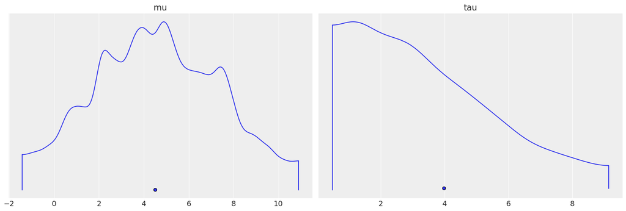

```julia
begin
    plot_density(stan_chns; var_names=(:mu, :tau))
    gcf()
end
```

Again, converting to `InferenceData`, we can get much richer labelling and mixing of data. Note that we're using the same [`from_cmdstan`](https://julia.arviz.org/stable/reference/#ArviZ.from_cmdstan) function used by ArviZ to process cmdstan output files, but through the power of dispatch in Julia, if we pass a `Chains` object, it instead uses ArviZ.jl's overloads, which forward to `from_mcmcchains`.

```julia
idata_stan = from_cmdstan(
    stan_chns;
    posterior_predictive=:y_hat,
    observed_data=(; y),
    log_likelihood=:log_lik,
    coords=(; school=schools),
    dims=NamedTuple(k => (:school,) for k in (:y, :sigma, :theta, :log_lik, :y_hat)),
)
```

InferenceData

**posterior**

```
Dataset with dimensions:
  Dim{:chain} Sampled 1:4 ForwardOrdered Regular Points,
  Dim{:draw} Sampled 1:1000 ForwardOrdered Regular Points,
  Dim{:school} Categorical String[Choate, Deerfield, …, St. Paul's, Mt. Hermon] Unordered
and 3 layers:
  :mu    Float64 dims: Dim{:chain}, Dim{:draw} (4×1000)
  :theta Float64 dims: Dim{:chain}, Dim{:draw}, Dim{:school} (4×1000×8)
  :tau   Float64 dims: Dim{:chain}, Dim{:draw} (4×1000)

with metadata OrderedCollections.OrderedDict{Symbol, Any} with 4 entries:
  :created_at => "2022-07-27T05:43:49.72"
  :arviz_version => "0.6.0"
  :arviz_language => "julia"
  :inference_library => "CmdStan"
```

**posterior_predictive**

```
Dataset with dimensions:
  Dim{:chain} Sampled 1:4 ForwardOrdered Regular Points,
  Dim{:draw} Sampled 1:1000 ForwardOrdered Regular Points,
  Dim{:school} Categorical String[Choate, Deerfield, …, St. Paul's, Mt. Hermon] Unordered
and 1 layer:
  :y_hat Float64 dims: Dim{:chain}, Dim{:draw}, Dim{:school} (4×1000×8)

with metadata OrderedCollections.OrderedDict{Symbol, Any} with 4 entries:
  :created_at => "2022-07-27T05:43:48.465"
  :arviz_version => "0.6.0"
  :arviz_language => "julia"
  :inference_library => "CmdStan"
```

**log_likelihood**

```
Dataset with dimensions:
  Dim{:chain} Sampled 1:4 ForwardOrdered Regular Points,
  Dim{:draw} Sampled 1:1000 ForwardOrdered Regular Points,
  Dim{:school} Categorical String[Choate, Deerfield, …, St. Paul's, Mt. Hermon] Unordered
and 1 layer:
  :log_lik Float64 dims: Dim{:chain}, Dim{:draw}, Dim{:school} (4×1000×8)

with metadata OrderedCollections.OrderedDict{Symbol, Any} with 4 entries:
  :created_at => "2022-07-27T05:43:49.009"
  :arviz_version => "0.6.0"
  :arviz_language => "julia"
  :inference_library => "CmdStan"
```

**sample_stats**

```
Dataset with dimensions:
  Dim{:chain} Sampled 1:4 ForwardOrdered Regular Points,
  Dim{:draw} Sampled 1:1000 ForwardOrdered Regular Points
and 7 layers:
  :tree_depth      Int64 dims: Dim{:chain}, Dim{:draw} (4×1000)
  :n_steps         Int64 dims: Dim{:chain}, Dim{:draw} (4×1000)
  :lp              Float64 dims: Dim{:chain}, Dim{:draw} (4×1000)
  :step_size       Float64 dims: Dim{:chain}, Dim{:draw} (4×1000)
  :energy          Float64 dims: Dim{:chain}, Dim{:draw} (4×1000)
  :diverging       Bool dims: Dim{:chain}, Dim{:draw} (4×1000)
  :acceptance_rate Float64 dims: Dim{:chain}, Dim{:draw} (4×1000)

with metadata OrderedCollections.OrderedDict{Symbol, Any} with 4 entries:
  :created_at => "2022-07-27T05:43:49.69"
  :arviz_version => "0.6.0"
  :arviz_language => "julia"
  :inference_library => "CmdStan"
```

**observed_data**

```
Dataset with dimensions:
  Dim{:school} Categorical String[Choate, Deerfield, …, St. Paul's, Mt. Hermon] Unordered
and 1 layer:
  :y Float64 dims: Dim{:school} (8)

with metadata OrderedCollections.OrderedDict{Symbol, Any} with 4 entries:
  :created_at => "2022-07-27T05:43:50.391"
  :arviz_version => "0.6.0"
  :arviz_language => "julia"
  :inference_library => "CmdStan"
```

Here is a plot showing where the Hamiltonian sampler had divergences:

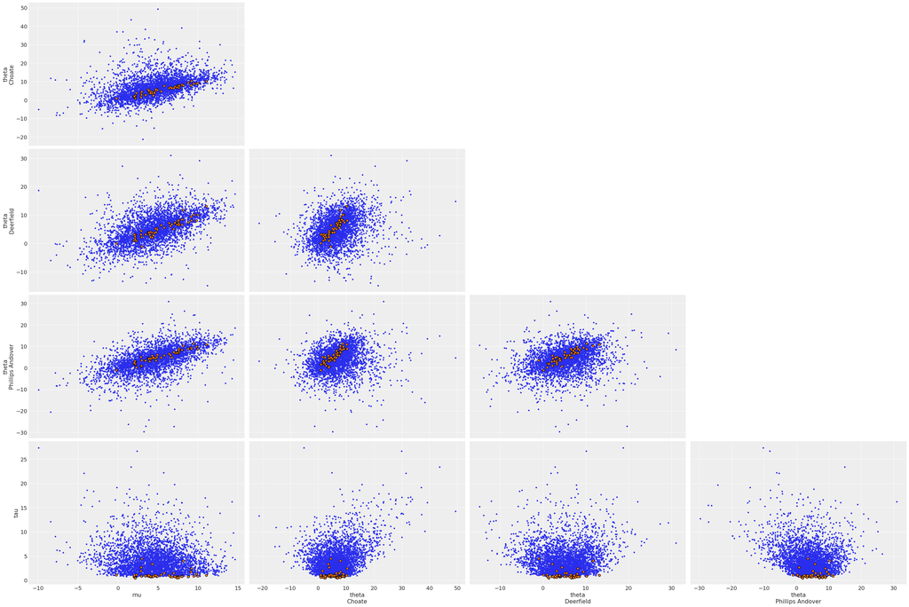

```julia
begin
    plot_pair(
        idata_stan;
        coords=Dict(:school => ["Choate", "Deerfield", "Phillips Andover"]),
        divergences=true,
    )
    gcf()
end
```

## Plotting with Soss.jl outputs

With Soss, we can define our model for the posterior and easily use it to draw samples from the prior, prior predictive, posterior, and posterior predictive distributions.

First we define our model:

```julia
constant_data = (; J, σ);
```

```julia
observed_data = (; y);
```

```julia
model_soss = Soss.@model (J, σ) begin
    μ ~ Soss.Normal(; μ=0, σ=5)
    τ ~ HalfCauchy(; σ=5)
    θ ~ Soss.Normal(; μ, σ=τ) |> iid(J)
    y ~ For(1:J) do j
        Soss.Normal(; μ=θ[j], σ=σ[j])
    end
end;
```

```julia
param_mod_soss = model_soss(; constant_data...)
```

```
ConditionalModel given
    arguments    (:J, :σ)
    observations ()
@model (J, σ) begin
        τ ~ HalfCauchy(; σ = 5)
        μ ~ Soss.Normal(; μ = 0, σ = 5)
        θ ~ Soss.Normal(; μ, σ = τ) |> iid(J)
        y ~ For(1:J) do j
                Soss.Normal(; μ = θ[j], σ = σ[j])
            end
    end
```

Then we draw from the prior and prior predictive distributions.

```julia
rng3 = MersenneTwister(5298);
```

```julia
prior_priorpred = let Normal = Soss.Normal
    [rand(rng3, param_mod_soss, ndraws) for _ in 1:nchains]
end
```

```
4-element Vector{TupleVectors.TupleVector{NamedTuple{(:τ, :μ, :θ, :y), Tuple{Float64, Float64, Vector{Float64}, Vector{Float64}}}, NamedTuple{(:τ, :μ, :θ, :y), Tuple{ElasticArrays.ElasticVector{Float64, Vector{Float64}}, ElasticArrays.ElasticVector{Float64, Vector{Float64}}, ArraysOfArrays.ArrayOfSimilarArrays{Float64, 1, 1, 2, ElasticArrays.ElasticMatrix{Float64, Vector{Float64}}}, ArraysOfArrays.ArrayOfSimilarArrays{Float64, 1, 1, 2, ElasticArrays.ElasticMatrix{Float64, Vector{Float64}}}}}}}
(τ = 17.0±87.0, μ = 0.2±5.1, θ = [-1.0±66.0, 2.0±72.0, 2.0±37.0, 3.0±130.0, -2.0±69.0, -1.0±50.0, -0.6±48.0, 0.8±47.0], y = [-1.0±68.0, 2.0±73.0, 2.0±41.0, 4.0±130.0, -2.0±69.0, -2.0±52.0, -0.0±48.0, 2.0±51.0])
(τ = 16.0±49.0, μ = -0.01±4.9, θ = [-0.8±60.0, -3.0±36.0, 0.6±37.0, -1.0±47.0, 0.6±48.0, 1.0±66.0, -2.0±39.0, -3.0±55.0], y = [-0.8±61.0, -3.0±38.0, -0.0±40.0, -1.0±48.0, 0.8±49.0, 1.0±67.0, -2.0±40.0, -3.0±58.0])
(τ = 27.0±160.0, μ = -0.2±4.9, θ = [-0.0±110.0, -3.0±160.0, -6.0±150.0, 2.0±57.0, 7.0±170.0, -1.0±96.0, -0.0±110.0, -3.0±180.0], y = [-0.1±110.0, -3.0±160.0, -5.0±150.0, 2.0±58.0, 7.0±170.0, -1.0±96.0, -0.0±120.0, -3.0±190.0])
(τ = 23.0±170.0, μ = -0.2±4.8, θ = [-1.0±91.0, 0.0±50.0, 4.0±75.0, 3.0±130.0, -5.0±210.0, 3.0±130.0, -1.0±48.0, 2.0±75.0], y = [-1.0±91.0, 0.1±51.0, 4.0±77.0, 3.0±130.0, -5.0±210.0, 3.0±130.0, -2.0±49.0, 2.0±78.0])
```

Next, we draw from the posterior using DynamicHMC.jl.

```julia
post = Soss.sample(rng3, param_mod_soss | observed_data, dynamichmc(), ndraws, nchains)
```

```
4000-element MultiChain with 4 chains and schema (τ = Float64, μ = Float64, θ = Vector{Float64})
(τ = 3.8±3.1, μ = 4.27±3.6, θ = [6.2±5.9, 4.9±5.1, 3.8±5.3, 4.6±5.0, 3.4±4.9, 3.9±5.2, 6.3±5.5, 4.6±5.5])
```

Finally, we update the posterior samples with draws from the posterior predictive distribution.

```julia
postpred = let
    mod_pred = Soss.predictive(model_soss, :μ, :τ, :θ)
    map(getchains(post)) do chain
        [rand(rng3, mod_pred(; constant_data..., draw...)) for draw in chain]
    end
end
```

[output not shown]

Each Soss draw is a `NamedTuple`. We can plot the rank order statistics of the posterior to identify poor convergence:

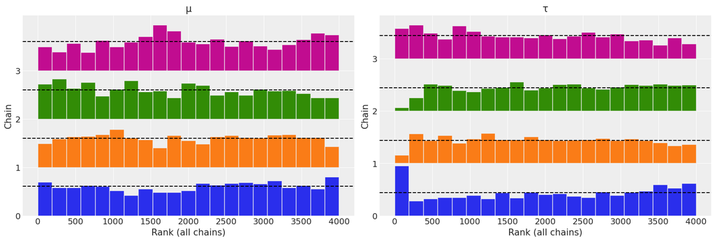

```julia
begin
    plot_rank(post; var_names=(:μ, :τ))
    gcf()
end
```

Now we combine all of the samples to an `InferenceData`:

```julia
idata_soss = from_samplechains(
    post;
    posterior_predictive=postpred,
    prior=prior_priorpred,
    prior_predictive=(:y,),
    observed_data,
    constant_data=(; J=[J], σ),
    coords=(; school=schools),
    dims=NamedTuple(k => (:school,) for k in (:y, :σ, :θ)),
    library=Soss,
)
```

InferenceData

**posterior**

```
Dataset with dimensions:
  Dim{:chain} Sampled 1:4 ForwardOrdered Regular Points,
  Dim{:draw} Sampled 1:1000 ForwardOrdered Regular Points,
  Dim{:school} Categorical String[Choate, Deerfield, …, St. Paul's, Mt. Hermon] Unordered
and 3 layers:
  :τ Float64 dims: Dim{:chain}, Dim{:draw} (4×1000)
  :μ Float64 dims: Dim{:chain}, Dim{:draw} (4×1000)
  :θ Float64 dims: Dim{:chain}, Dim{:draw}, Dim{:school} (4×1000×8)

with metadata OrderedCollections.OrderedDict{Symbol, Any} with 5 entries:
  :created_at => "2022-07-27T05:45:39.662"
  :arviz_version => "0.6.0"
  :arviz_language => "julia"
  :inference_library => "Soss"
  :inference_library_version => "0.20.9"
```

**posterior_predictive**

```
Dataset with dimensions:
  Dim{:chain} Sampled 1:4 ForwardOrdered Regular Points,
  Dim{:draw} Sampled 1:1000 ForwardOrdered Regular Points,
  Dim{:school} Categorical String[Choate, Deerfield, …, St. Paul's, Mt. Hermon] Unordered
and 1 layer:
  :y Float64 dims: Dim{:chain}, Dim{:draw}, Dim{:school} (4×1000×8)

with metadata OrderedCollections.OrderedDict{Symbol, Any} with 5 entries:
  :created_at => "2022-07-27T05:45:39.412"
  :arviz_version => "0.6.0"
  :arviz_language => "julia"
  :inference_library => "Soss"
  :inference_library_version => "0.20.9"
```

**sample_stats**

```
Dataset with dimensions:
  Dim{:chain} Sampled 1:4 ForwardOrdered Regular Points,
  Dim{:draw} Sampled 1:1000 ForwardOrdered Regular Points
and 6 layers:
  :energy          Float64 dims: Dim{:chain}, Dim{:draw} (4×1000)
  :tree_depth      Int64 dims: Dim{:chain}, Dim{:draw} (4×1000)
  :acceptance_rate Float64 dims: Dim{:chain}, Dim{:draw} (4×1000)
  :n_steps         Int64 dims: Dim{:chain}, Dim{:draw} (4×1000)
  :diverging       Bool dims: Dim{:chain}, Dim{:draw} (4×1000)
  :turning         Bool dims: Dim{:chain}, Dim{:draw} (4×1000)

with metadata OrderedCollections.OrderedDict{Symbol, Any} with 5 entries:
  :created_at => "2022-07-27T05:45:39.543"
  :arviz_version => "0.6.0"
  :arviz_language => "julia"
  :inference_library => "Soss"
  :inference_library_version => "0.20.9"
```

**prior**

```
Dataset with dimensions:
  Dim{:chain} Sampled 1:4 ForwardOrdered Regular Points,
  Dim{:draw} Sampled 1:1000 ForwardOrdered Regular Points,
  Dim{:school} Categorical String[Choate, Deerfield, …, St. Paul's, Mt. Hermon] Unordered
and 3 layers:
  :τ Float64 dims: Dim{:chain}, Dim{:draw} (4×1000)
  :μ Float64 dims: Dim{:chain}, Dim{:draw} (4×1000)
  :θ Float64 dims: Dim{:chain}, Dim{:draw}, Dim{:school} (4×1000×8)

with metadata OrderedCollections.OrderedDict{Symbol, Any} with 5 entries:
  :created_at => "2022-07-27T05:45:40.828"
  :arviz_version => "0.6.0"
  :arviz_language => "julia"
  :inference_library => "Soss"
  :inference_library_version => "0.20.9"
```

**prior_predictive**

```
Dataset with dimensions:
  Dim{:chain} Sampled 1:4 ForwardOrdered Regular Points,
  Dim{:draw} Sampled 1:1000 ForwardOrdered Regular Points,
  Dim{:school} Categorical String[Choate, Deerfield, …, St. Paul's, Mt. Hermon] Unordered
and 1 layer:
  :y Float64 dims: Dim{:chain}, Dim{:draw}, Dim{:school} (4×1000×8)

with metadata OrderedCollections.OrderedDict{Symbol, Any} with 5 entries:
  :created_at => "2022-07-27T05:45:40.828"
  :arviz_version => "0.6.0"
  :arviz_language => "julia"
  :inference_library => "Soss"
  :inference_library_version => "0.20.9"
```

**observed_data**

```
Dataset with dimensions:
  Dim{:school} Categorical String[Choate, Deerfield, …, St. Paul's, Mt. Hermon] Unordered
and 1 layer:
  :y Float64 dims: Dim{:school} (8)

with metadata OrderedCollections.OrderedDict{Symbol, Any} with 5 entries:
  :created_at => "2022-07-27T05:45:40.999"
  :arviz_version => "0.6.0"
  :arviz_language => "julia"
  :inference_library => "Soss"
  :inference_library_version => "0.20.9"
```

**constant_data**

```
Dataset with dimensions:
  Dim{:J_dim_1} Sampled 1:1 ForwardOrdered Regular Points,
  Dim{:school} Categorical String[Choate, Deerfield, …, St. Paul's, Mt. Hermon] Unordered
and 2 layers:
  :J Int64 dims: Dim{:J_dim_1} (1)
  :σ Float64 dims: Dim{:school} (8)

with metadata OrderedCollections.OrderedDict{Symbol, Any} with 5 entries:
  :created_at => "2022-07-27T05:45:41.341"
  :arviz_version => "0.6.0"
  :arviz_language => "julia"
  :inference_library => "Soss"
  :inference_library_version => "0.20.9"
```

We can compare the prior and posterior predictive distributions:

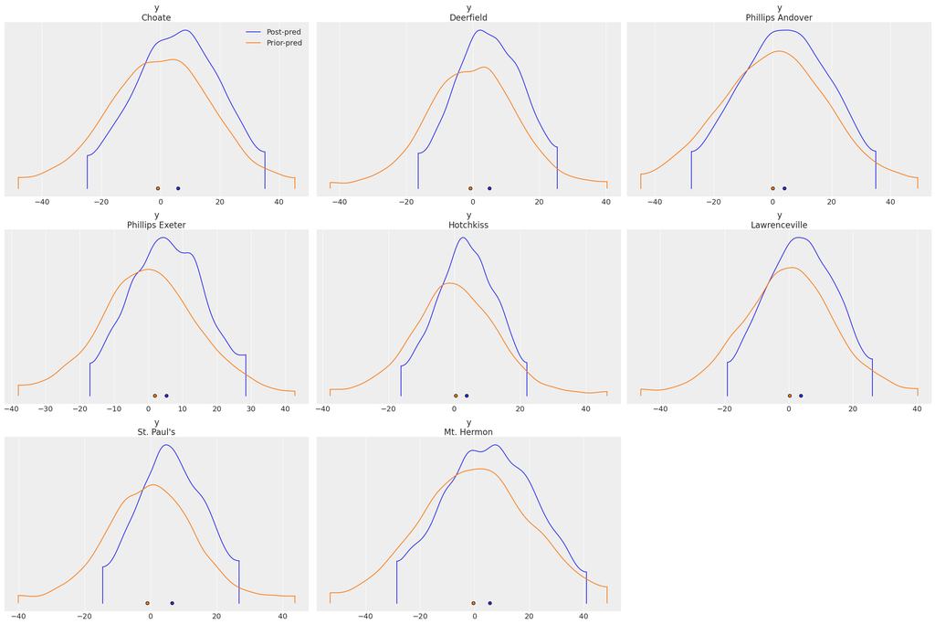

```julia
begin
    plot_density(
        [idata_soss.posterior_predictive, idata_soss.prior_predictive];
        data_labels=["Post-pred", "Prior-pred"],
        var_names=(:y,),
    )
    gcf()
end
```

## Environment

```julia
using PlutoUI
```

```julia
using Pkg, InteractiveUtils
```

```julia
with_terminal(Pkg.status; color=false)
```

```
      Status `~/work/ArviZ.jl/ArviZ.jl/docs/Project.toml`
  [cbdf2221] AlgebraOfGraphics v0.6.9
  [131c737c] ArviZ v0.6.0 `~/work/ArviZ.jl/ArviZ.jl`
  [13f3f980] CairoMakie v0.8.9
  [593b3428] CmdStan v6.6.0
  [a93c6f00] DataFrames v1.3.4
  [0703355e] DimensionalData v0.20.11
  [31c24e10] Distributions v0.25.66
  [e30172f5] Documenter v0.27.22
  [c7f686f2] MCMCChains v5.3.1
  [359b1769] PlutoStaticHTML v5.0.13
  [7f904dfe] PlutoUI v0.7.39
  [438e738f] PyCall v1.93.1
  [d330b81b] PyPlot v2.10.0
  [754583d1] SampleChains v0.5.1
  [6d9fd711] SampleChainsDynamicHMC v0.3.5
  [b2aef97b] SimplePosets v0.1.5
  [8ce77f84] Soss v0.20.9
  [fce5fe82] Turing v0.21.9
  [f43a241f] Downloads
  [37e2e46d] LinearAlgebra
```

```julia
with_terminal(versioninfo)
```

```
Julia Version 1.7.3
Commit 742b9abb4d (2022-05-06 12:58 UTC)
Platform Info:
  OS: Linux (x86_64-pc-linux-gnu)
  CPU: Intel(R) Xeon(R) Platinum 8171M CPU @ 2.60GHz
  WORD_SIZE: 64
  LIBM: libopenlibm
  LLVM: libLLVM-12.0.1 (ORCJIT, skylake-avx512)
Environment:
  JULIA_CMDSTAN_HOME = /home/runner/work/ArviZ.jl/ArviZ.jl/.cmdstan//cmdstan-2.25.0/
  JULIA_NUM_THREADS = 2
  JULIA_REVISE_WORKER_ONLY = 1
```